# Investigating factors that influences Life Expectancy

## Index

page 3 - Project’s aim

page 4 - Dataset Overview

page 6 - Basic analysis of the dataset

page 20 - Linear regression models

page 24 - Gam models

page 26 - Comments

## Project’s aim

- Does life expectancy differ in different regions?
- What factors are significant in determining life expectancy?

## Dataset Overview

The source of the data was a UN publication, UN Human Development Report. The data comprises national health related official statistics for 185 countries and 15 variables. As a measure of the average quality of health care the variable **LIFEEXP** may be used.

Not all countries provided information for each variable. Data not available are noted under the column **NA**.

Ignoring the variables **REGION** and **COUNTRY** the remaining 13 numeric variables are summarized in Table 1.

Table 1: UN National Life Expectancy in 185 Counties

| Name | Description | NA | Mean | Median |
| --- | --- | --- | --- | --- |
| LIFEEXP | Life expectancy at birth (in years) | 0 | 67 | 71 |
| ILLITERATE | Adult illiteracy rate (% aged 15 and older) | 14 | 18 | 10 |
| POP | 2005 population (in millions) | 1 | 35 | 8 |
| FERTILITY | Total fertility rate (births per woman) | 4 | 3 | 3 |
| PRIVATEHEALTH | 2004 private expenditure on health (% of GDP) | 1 | 3 | 2 |
| PUBLICEDUCATION | Public expenditure on education (% of GDP) | 28 | 5 | 5 |
| HEALTHEXPEND | 2004 health expenditure per capita (PPP in USD) | 5 | 718 | 298 |
| BIRTHATTEND | Births attended by skilled health personnel (%) | 7 | 78 | 92 |
| PHYSICIAN | Physicians per 100k people | 3 | 146 | 108 |
| SMOKING | Prevalence of smoking (male % of adults) | 88 | 35 | 32 |
| RESEARCHERS | Researchers in R&D (per million people) | 95 | 2035 | 848 |
| GDP | Gross domestic product (in billions of USD ) | 7 | 248 | 14 |
| FEMALEBOSS | Legislators senior officials and managers = % female | 87 | 29 | 30 |

Notably, some variables exhibit a significant number of missing values, such as **SMOKING**, **RESEARCHERS**, **PUBLICEDUCATION**, and **FEMALEBOSS**, it seems that many countries don’t have this data. Consequently, these variables will be excluded from the analysis.

Data from Hong kong and Somalia has been removed since too many variables were NA.

Table 2: Regions are -1- Middle East and North Africa -2- South-east Asia -3- Central and South America -4- Central Asia -5- Turkey Ethiopia Cyprus -6- Africa -7- East Europe Russia and -STAN countries -8- Europe, North America, Australia, New Zeland

| REGION | ILLITERATE | POP | FERTILITY | PRIVATEHEALTH | HEALTHEXPEND | BIRTHATTEND | PHYSICIAN | GDP |
| --- | --- | --- | --- | --- | --- | --- | --- | --- |
| 1 | 1 | 0 | 0 | 0 | 1 | 0 | 1 | 0 |
| 2 | 1 | 0 | 0 | 0 | 0 | 0 | 1 | 3 |
| 3 | 5 | 1 | 3 | 0 | 0 | 0 | 0 | 1 |
| 4 | 0 | 0 | 0 | 0 | 0 | 0 | 0 | 0 |
| 5 | 0 | 0 | 0 | 0 | 0 | 0 | 0 | 0 |
| 6 | 5 | 0 | 1 | 0 | 0 | 1 | 0 | 0 |
| 7 | 0 | 0 | 0 | 0 | 2 | 0 | 0 | 2 |
| 8 | 0 | 0 | 0 | 0 | 0 | 5 | 0 | 0 |

## Basic analysis

**ILLITERATE** has a high number of missing values and region 3 and 6 has the most of them but values are similar in every region we consider.

**BIRTHATTEND** has 5 NA in region 8. But the value is similar to all rows in region 8.

Region 5 is the only region that has only 3 countries but no NA. These 3 countries has been moved from region 5 to other regions that have similar values (Turkey to region 1, Cyprus to region 7 and Ethiopia to region 6). Djibouti has been moved to region 6 for the same reason.

Other regions have sufficient values so that, for the other missing values **we will impute them using mean** (for example a NA of gdp in region 8 in evaluated with the gdp mean of the region 8).

## Variables summary

Looking at the table above in average, the life expectancy has mean of 67. And 50% of countries has a life expectancy below 71 years and 25% below 60 years.

```
   Min. 1st Qu.  Median    Mean 3rd Qu.    Max.
  40.50   60.25   71.00   67.08   75.05   82.30
```

## 25% of countries with

**the lowest life expectancy**

let’s delve into an analysis of the 25% of countries with the lowest life expectancy. Within this subset of countries, we observe some distinctive patterns. The mean **illiteracy** rate stands at **37**, notably higher than the overall average of **17.7** for all countries. Additionally, the average **fertility** rate within this group is **5.4**, which exceeds the global average of **3.2**. Furthermore, it’s worth mentioning that the average value of **births attended by skilled health personnel** for these countries is **49.6%**, significantly lower than the overall global average of **78.2%**. Finally, within this segment of countries, the average **health expenditure** is only **126**, which starkly contrasts with the global average of **718** for all countries.

**highest life expectancy**

In contrast, the 25% of countries with the highest life expectancy exhibit significantly more favorable indicators. This group allocates a substantial amount of resources to healthcare, with an average **health expenditure** of **1,953**, surpassing the overall average of **718**. Furthermore, they demonstrate a lower mean **illiteracy** rate of **4.7**, boast a higher **GDP** at **755**, and achieve a remarkable **96%** **attendance rate for births**, all of which stand in stark contrast to the global averages.

## Life Expectancy

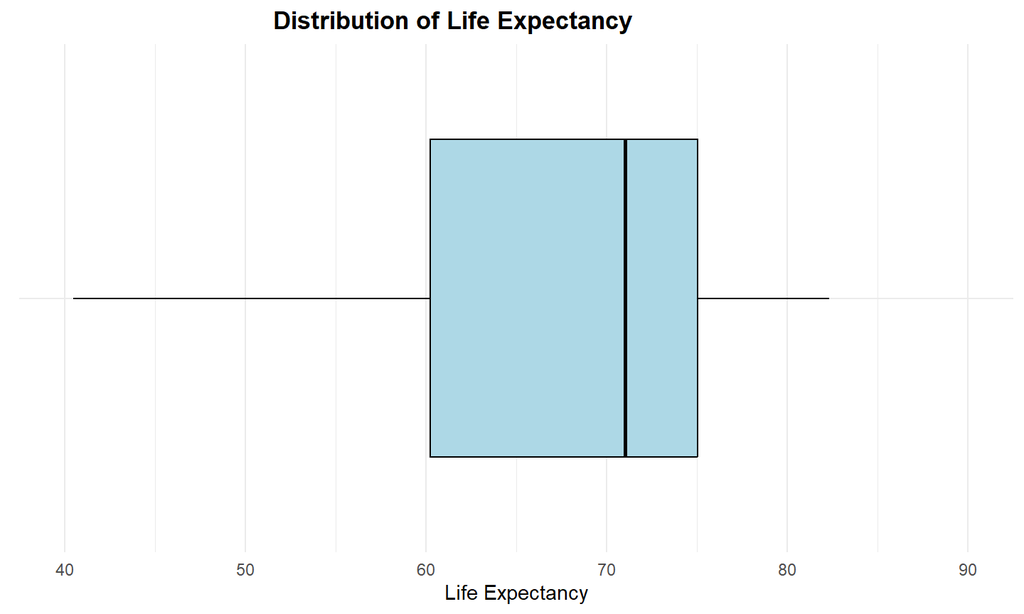

- Life expectancy is negatively skewed.
- There are no outliers in the life expectancy
- Region 8 has the highest average Life expectancy while region 6 has the lowest
- Region 1, 3, and 4 have outlier life expectancy where some people have very low life expectancy
- Region 1, 3, 4 and 6 have outliers

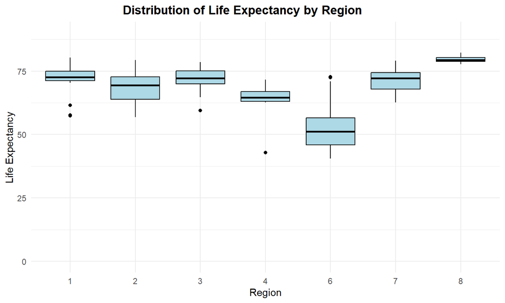

## Distribution of Numeric Variables

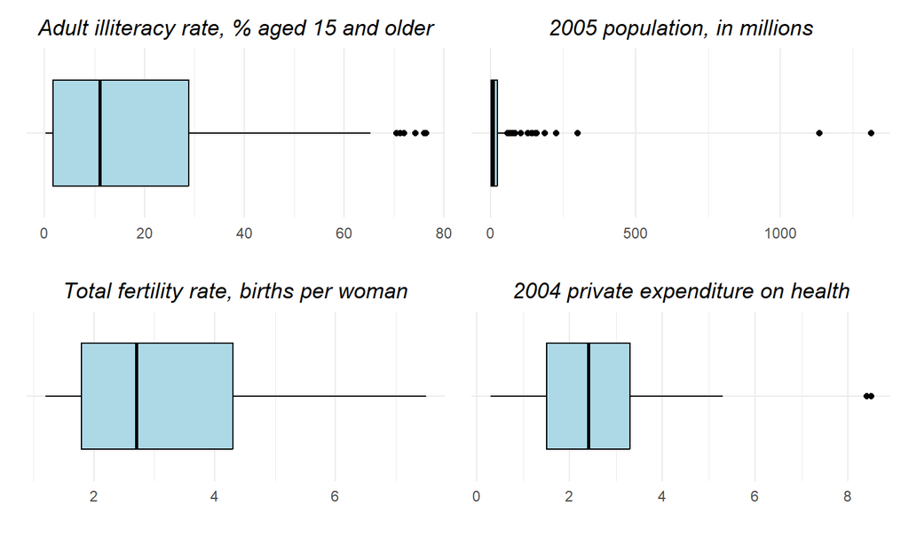

## Distribution of Numeric Variables

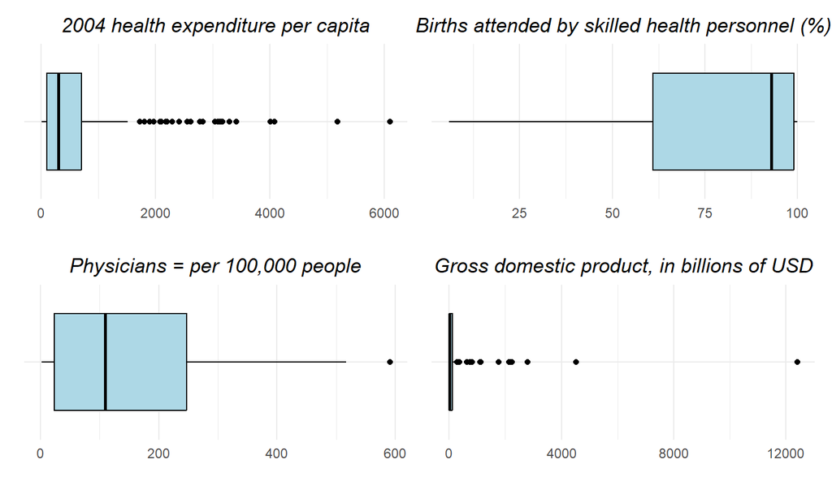

## Life Expectancy and Independent Variables

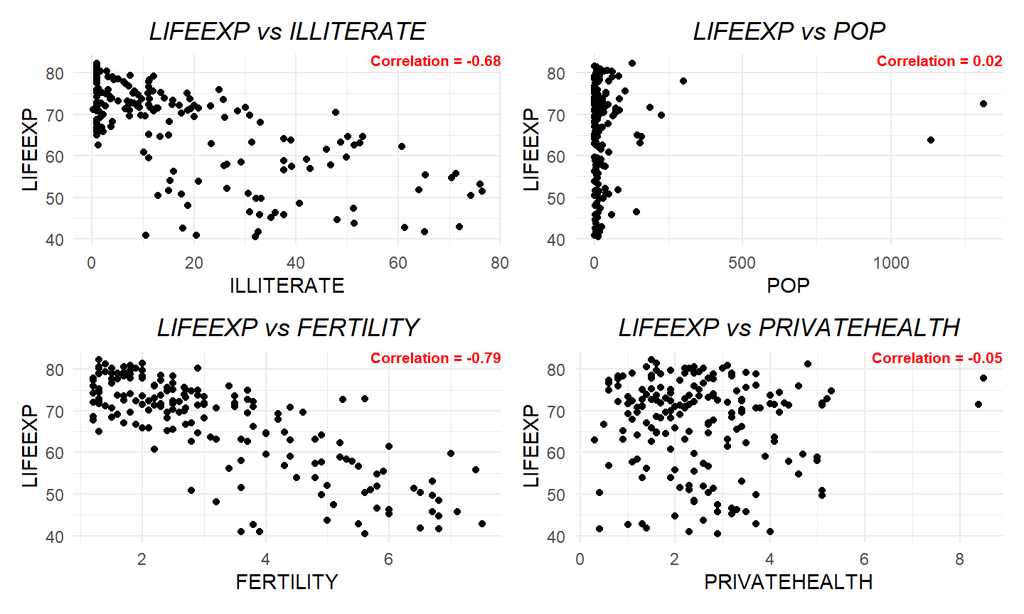

## Life Expectancy and Independent Variables

- There is a strong negative relationship between **LIFEEXP** and **ILLITERATE** as well as **LIFEEXP** and **FERTILITY**. This implies that an increase in ILLITERATE and FERTILITY leads to a decrease in LIFEEXP
- There is no correlation between **LIFEEXP** and **POP** as well as **LIFEEXP** and **PRIVATEHEALTH**.

## Life Expectancy and Independent Variables

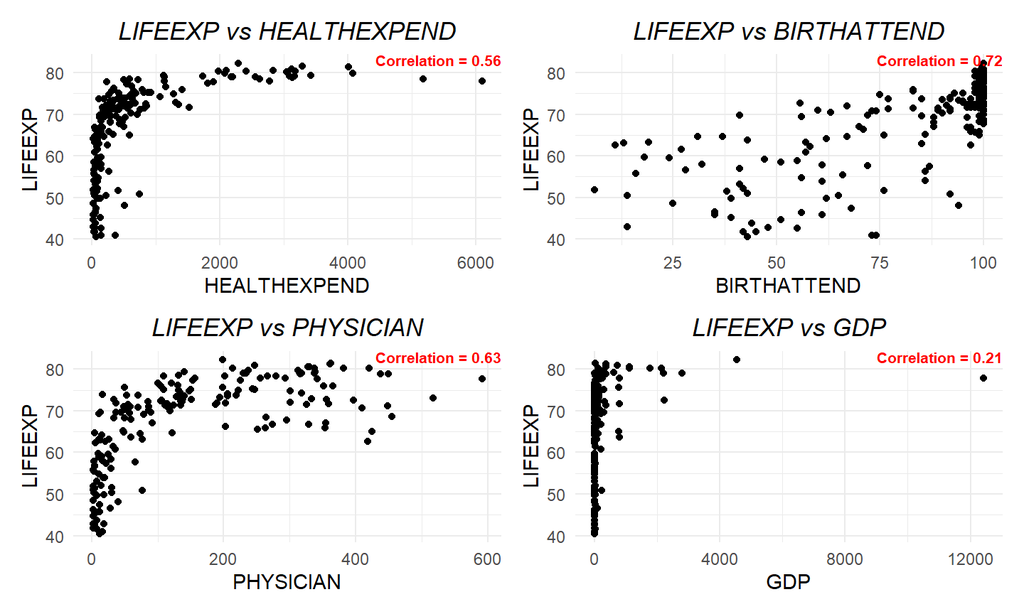

## Life Expectancy and Independent Variables

- The chart in the previous slide, shows that **HEALTHEXPEND**, **BIRTHATTEND**, and **PHYSICIAN** have moderate positive linear relationship with **LIFEEXP**. This implies that an increase in these variables moderately increases the LIFEEXP
- There is a weak positive linear relationship between **GDP** and **LIFEEXP**. But if we use the logarithm:

[figure not shown]

## Correlation chart

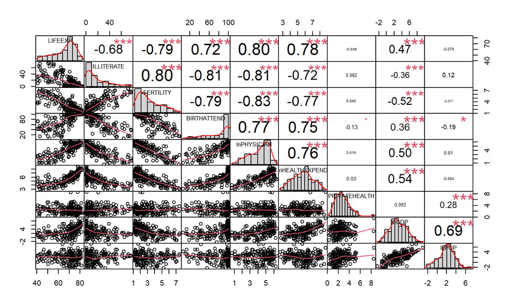

## Distribution of Life Expectancy

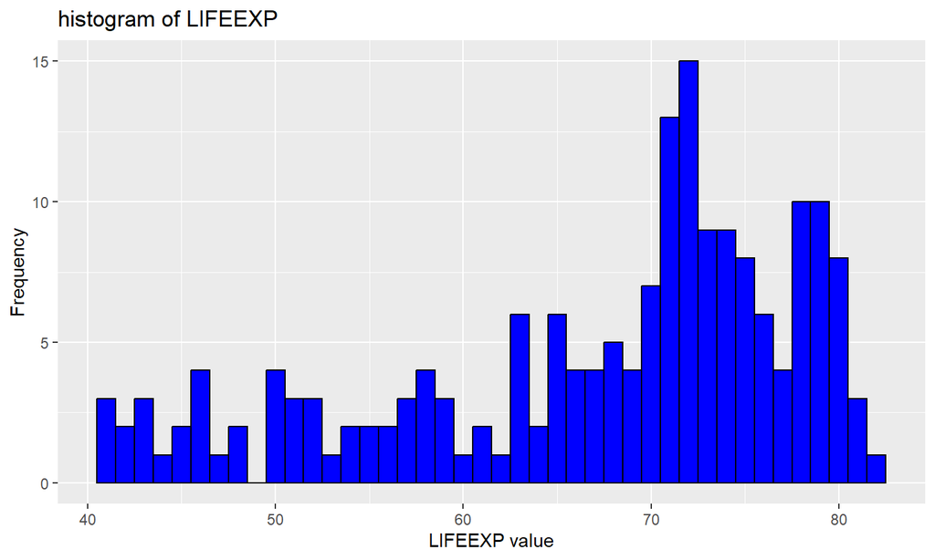

- In the figure above, we observe that the ‘LIFEEXP’ variable exhibits a **left-skewed distribution**.
- In the following part, linear models will be created using LIFEEXP as response variable

## Linear regression models

- The first model has only **lnPHYSICIAN** as explanatory variable. This variable shows the **highest correlation** with LIFEEXP.
- With the same logic, subsequent models add **lnHEALTHEXPEND, FERTILITY and REGION** and different metrics has been evaluated.
- The **adjusted R squared increase** from 0.64 to 0.79 and The **F statistic** slightly decrease.
- here is the summary of the linear model with **LIFEEXP ~ lnPHYSICIAN + lnHEALTHEXPEND + FERTILITY + REGION**

```
Call:
lm(formula = LIFEEXP ~ lnPHYSICIAN + lnHEALTHEXPEND + FERTILITY +
    REGION, data = data)

Residuals:
     Min       1Q   Median       3Q      Max
-16.7192  -1.9648   0.1603   2.9219  12.9193

Coefficients:
               Estimate Std. Error t value Pr(>|t|)
(Intercept)     57.8485     5.0470  11.462  < 2e-16 ***
lnPHYSICIAN      1.5056     0.5573   2.702  0.00758 **
lnHEALTHEXPEND   1.8661     0.5646   3.305  0.00116 **
FERTILITY       -1.3282     0.4864  -2.731  0.00697 **
REGION2         -0.8483     1.6435  -0.516  0.60641
REGION3         -0.4351     1.4325  -0.304  0.76168
REGION4         -3.9510     2.1267  -1.858  0.06489 .
REGION6        -10.2437     1.7150  -5.973 1.29e-08 ***
REGION7         -4.0484     1.5886  -2.548  0.01169 *
REGION8          0.4170     1.7777   0.235  0.81483
---
Signif. codes:  0 '***' 0.001 '**' 0.01 '*' 0.05 '.' 0.1 ' ' 1

Residual standard error: 4.932 on 173 degrees of freedom
Multiple R-squared:  0.8085,    Adjusted R-squared:  0.7985
F-statistic: 81.15 on 9 and 173 DF,  p-value: < 2.2e-16
```

## Linear regression models

-All numerical variables seem to be very significant. Regarding the categorical variable **REGION**, Africa, as expected, shows a much lower life expectancy compared to REGION 1 used for comparison.

- VIF has been used to check for collinearity among covariates.

```
                   GVIF Df GVIF^(1/(2*Df))
lnPHYSICIAN    5.154330  1        2.270315
lnHEALTHEXPEND 4.643333  1        2.154840
FERTILITY      5.002569  1        2.236642
REGION         7.083625  6        1.177212
```

- Subsequent models did not overall improve the model, particularly considering the adjusted R-squared.
- Nonetheless, interaction with **REGION** was tested for each variable; however, no significant interactions were found.

## Linear regression models

- We can notice heteroscedasticity and a qqplot that does not fully reflect the assumptions of linear models. To address this heteroscedasticity, weighted least squares method has been used in subsequent models. Results do not differ much from the models with no WLS.

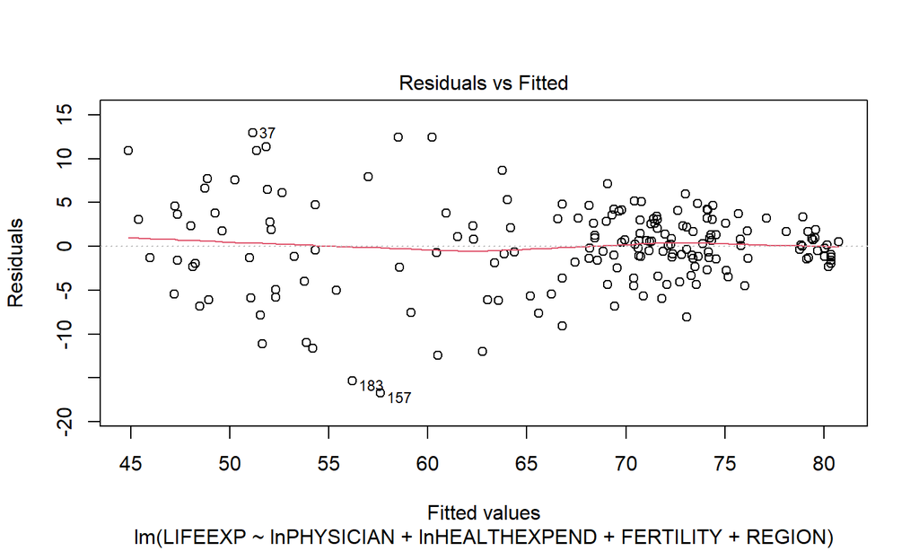

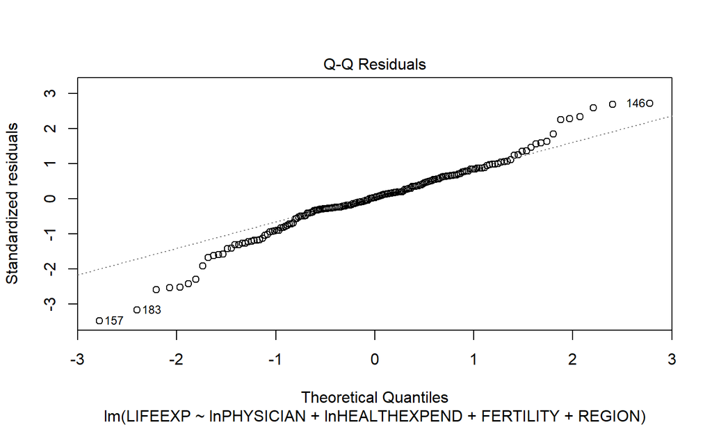

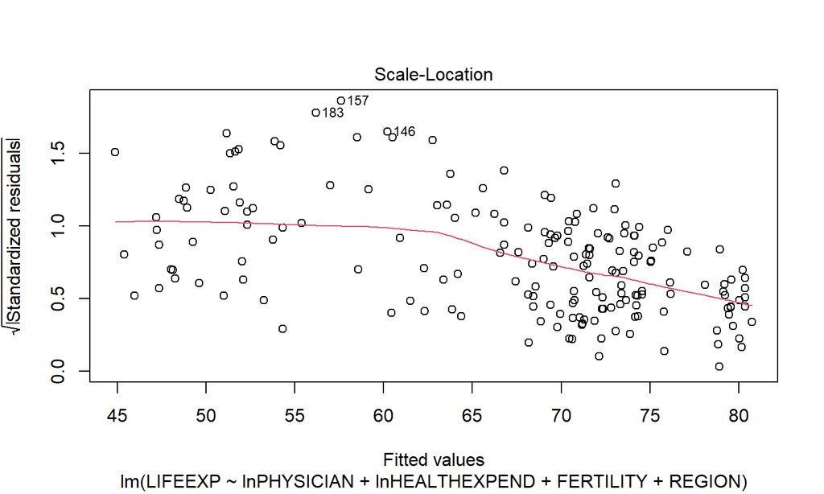

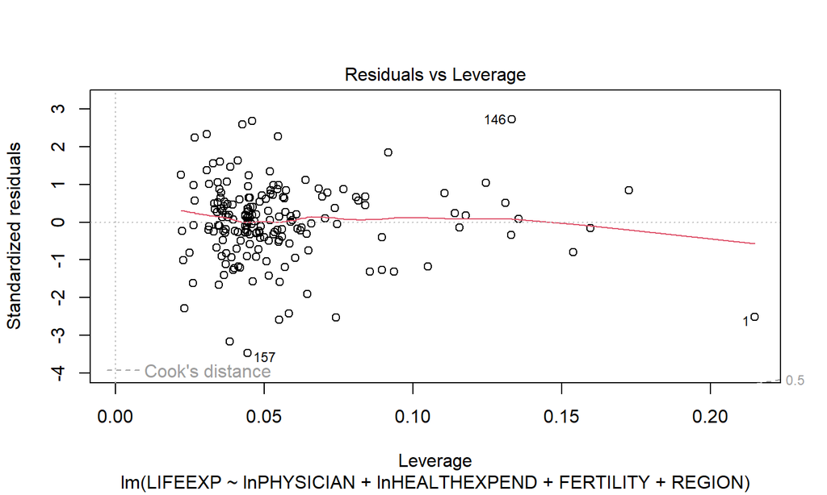

## Linear regression models

- The residual plots/explanatory variables do not show particular patterns.

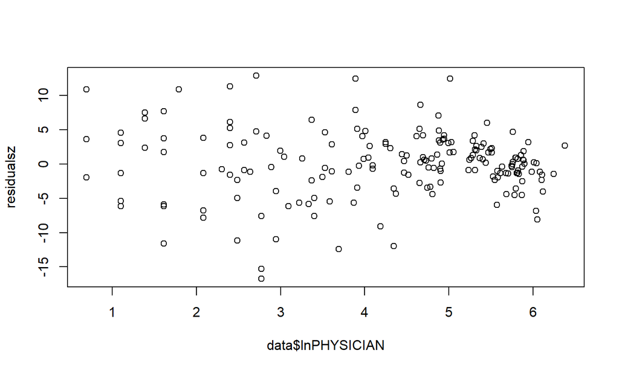

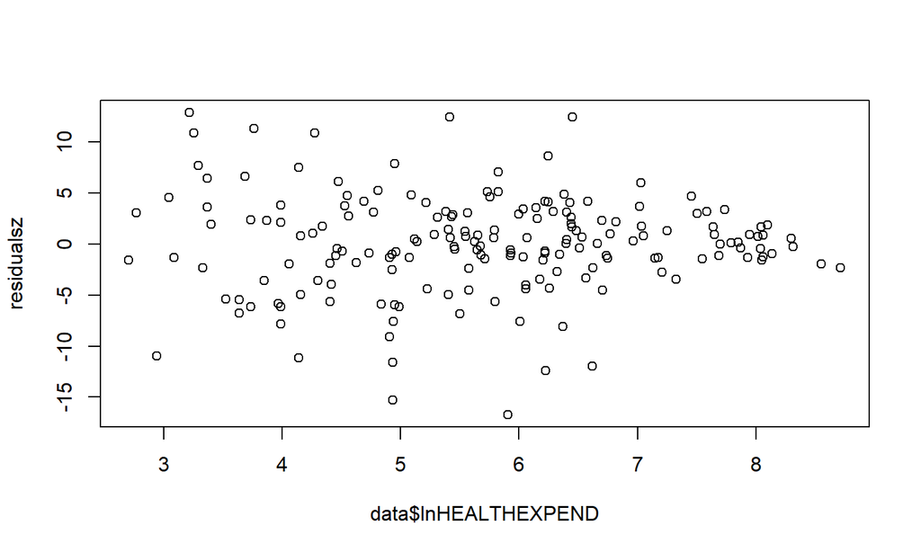

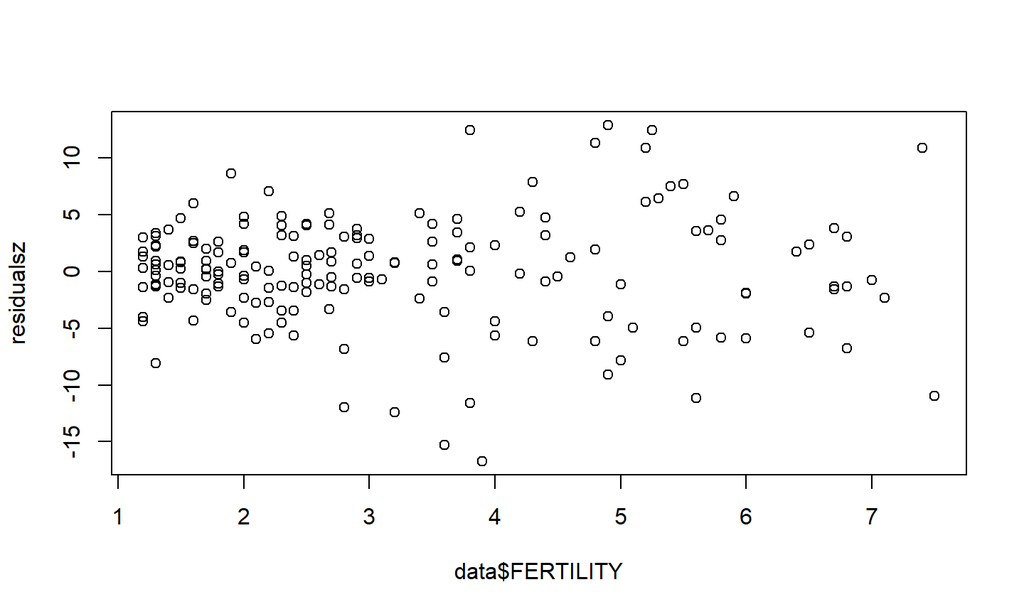

## GAM models

Afterward, different GAM models were implemented; as a test, the following model has all numerical variables included using a spline.

```
Family: gaussian
Link function: identity

Formula:
LIFEEXP ~ s(ILLITERATE) + s(FERTILITY) + s(PRIVATEHEALTH) + s(BIRTHATTEND) +
    s(PHYSICIAN) + s(HEALTHEXPEND) + s(GDP) + s(POP) + REGION

Parametric coefficients:
            Estimate Std. Error t value Pr(>|t|)
(Intercept)   69.457      1.276  54.424  < 2e-16 ***
REGION2        1.240      1.693   0.733    0.465
REGION3        0.782      1.484   0.527    0.599
REGION4       -2.459      2.248  -1.094    0.276
REGION6       -9.052      1.710  -5.294 3.89e-07 ***
REGION7       -2.212      1.974  -1.121    0.264
REGION8        0.717      2.988   0.240    0.811
---
Signif. codes:  0 '***' 0.001 '**' 0.01 '*' 0.05 '.' 0.1 ' ' 1

Approximate significance of smooth terms:
                   edf Ref.df     F p-value
s(ILLITERATE)    1.000  1.000 5.694  0.0182 *
s(FERTILITY)     2.268  2.871 3.615  0.0121 *
s(PRIVATEHEALTH) 3.758  4.604 0.671  0.7496
s(BIRTHATTEND)   1.000  1.000 3.532  0.0620 .
s(PHYSICIAN)     4.152  5.185 5.133  0.0002 ***
s(HEALTHEXPEND)  1.791  2.220 3.353  0.0375 *
s(GDP)           1.000  1.000 0.040  0.8413
s(POP)           1.000  1.000 0.223  0.6373
---
Signif. codes:  0 '***' 0.001 '**' 0.01 '*' 0.05 '.' 0.1 ' ' 1

R-sq.(adj) =   0.82   Deviance explained = 84.2%
GCV = 24.805  Scale est. = 21.692    n = 183
```

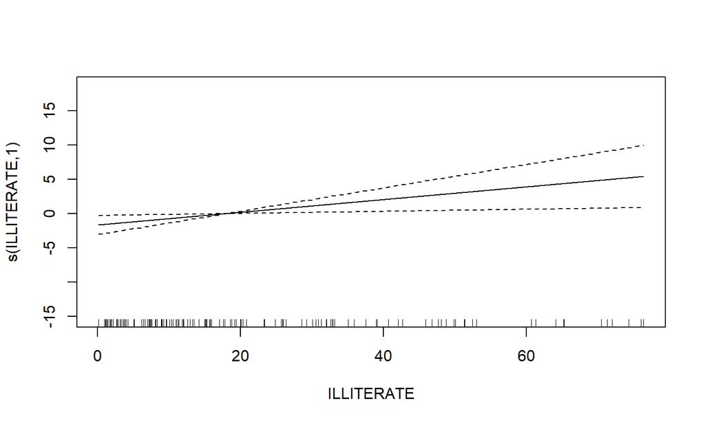

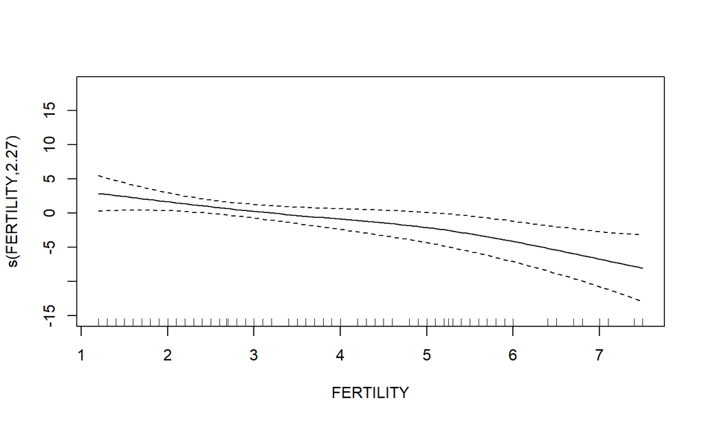

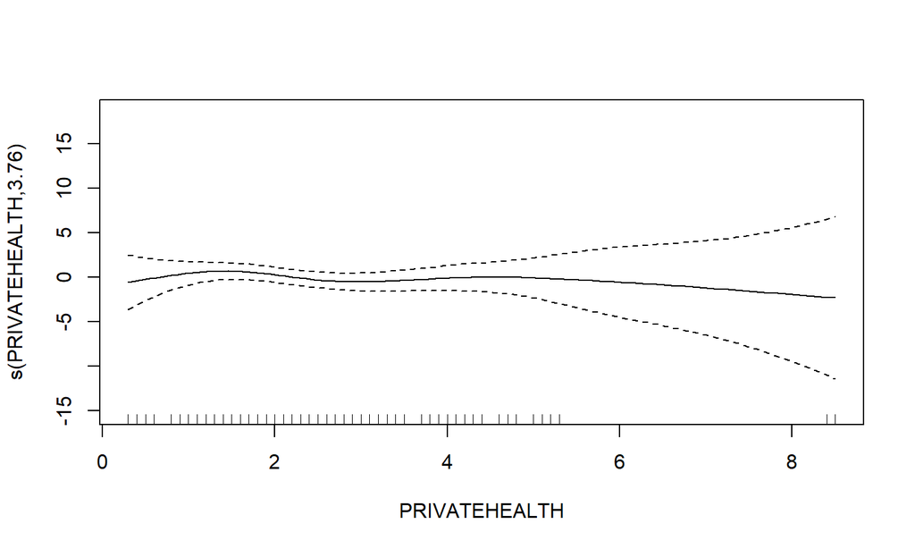

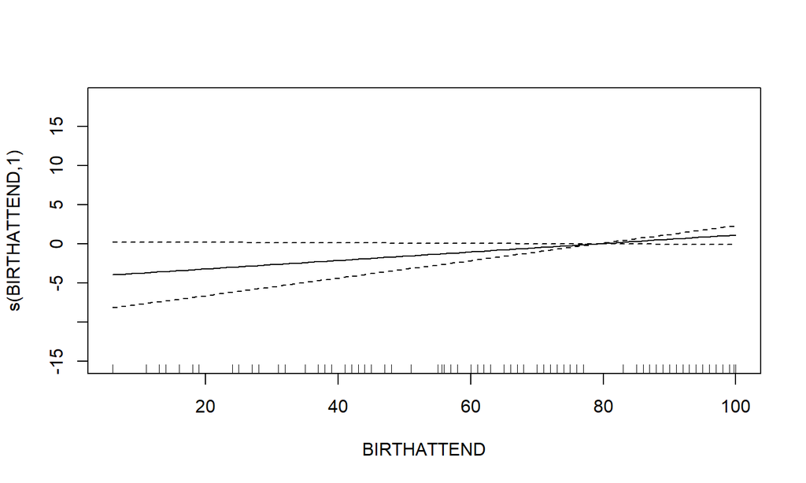

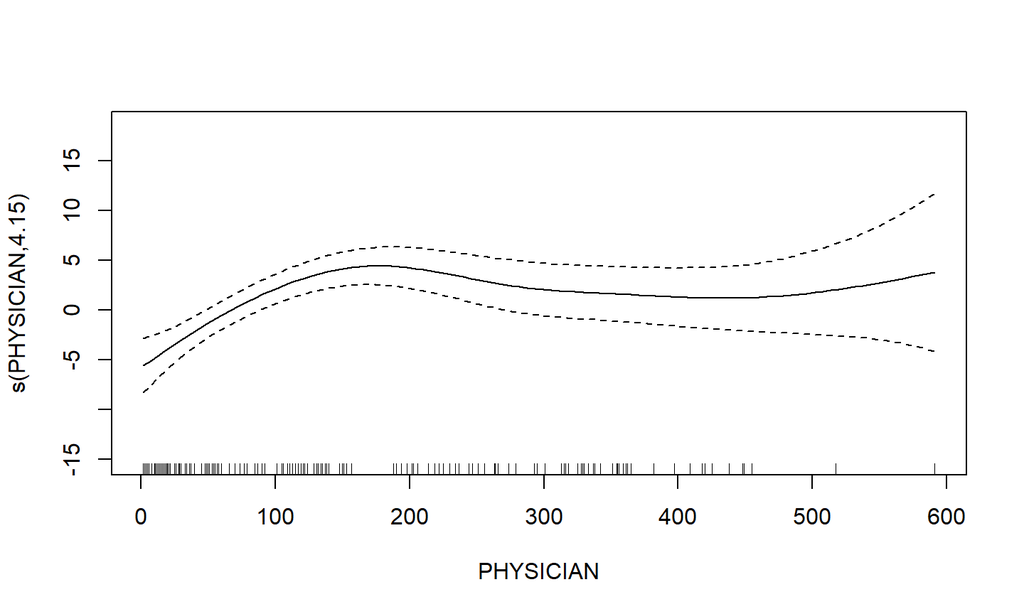

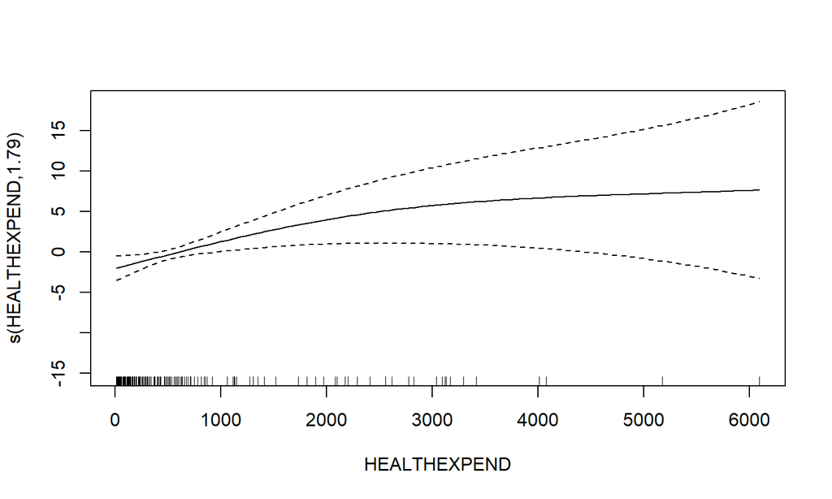

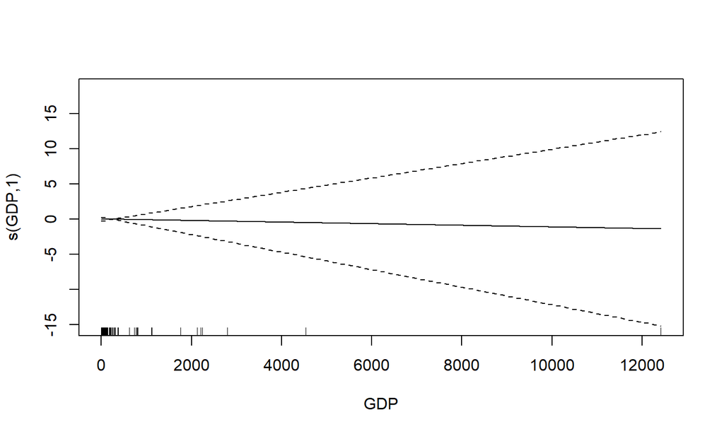

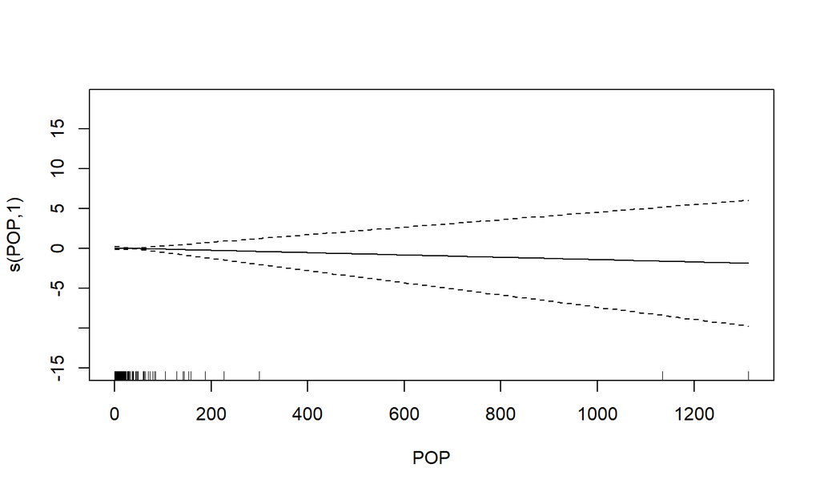

## GAM with few variables

Among the models implemented in GAM, considering the use of B-splines with multiple variables, the simplest model does not exhibit significantly different values of R-squared and deviance explained (as well as GCV and scale est.) compared to more complex models.

```
Family: gaussian
Link function: identity

Formula:
LIFEEXP ~ REGION + FERTILITY + s(PHYSICIAN) + s(HEALTHEXPEND)

Parametric coefficients:
            Estimate Std. Error t value Pr(>|t|)
(Intercept) 75.67960    1.88000  40.255  < 2e-16 ***
REGION2     -0.06705    1.60508  -0.042   0.9667
REGION3     -0.26054    1.39548  -0.187   0.8521
REGION4     -3.73653    2.05270  -1.820   0.0705 .
REGION6     -9.54133    1.66153  -5.742 4.24e-08 ***
REGION7     -3.45543    1.70623  -2.025   0.0444 *
REGION8     -0.34298    2.79116  -0.123   0.9023
FERTILITY   -1.67980    0.41898  -4.009 9.12e-05 ***
---
Signif. codes:  0 '***' 0.001 '**' 0.01 '*' 0.05 '.' 0.1 ' ' 1

Approximate significance of smooth terms:
                  edf Ref.df     F  p-value
s(PHYSICIAN)    3.909  4.904 4.836 0.000458 ***
s(HEALTHEXPEND) 2.006  2.502 3.453 0.029579 *
---
Signif. codes:  0 '***' 0.001 '**' 0.01 '*' 0.05 '.' 0.1 ' ' 1

R-sq.(adj) =  0.814   Deviance explained = 82.7%
GCV = 24.303  Scale est. = 22.455    n = 183
```

There are no interactions because they are missing in the previous linear regression model;

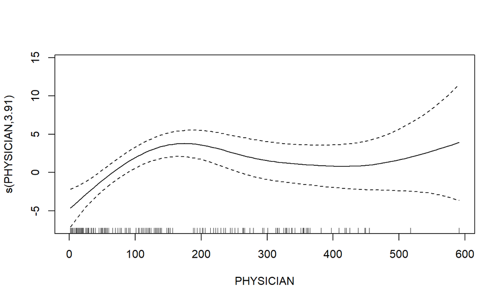

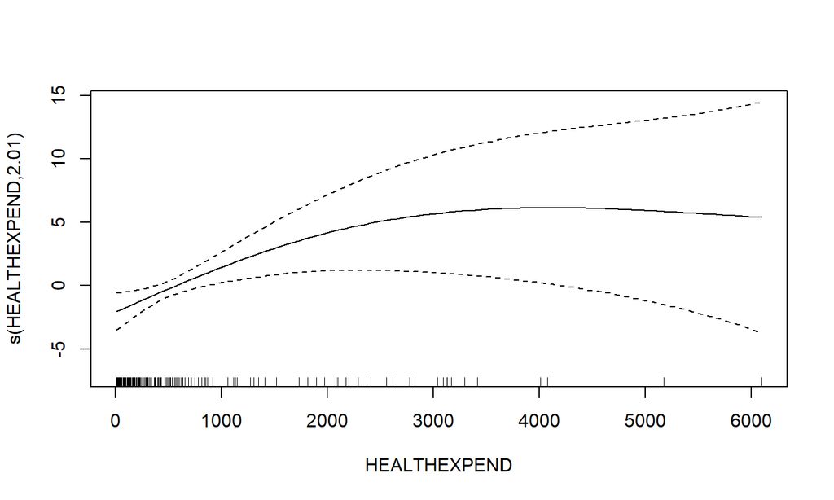